# HW4

HW4

Problem 0

```python
import scipy
from scipy import stats, signal
import numpy as np
import matplotlib
import matplotlib.pyplot as plt
plt.rcParams["figure.figsize"] = (15,10)
```

```python
t = np.linspace(0,np.pi*100,np.int(1e5))
N = 10+np.sin(t)
bkgd = stats.norm.rvs(size=np.int(1e5))*np.sqrt(N)+N
```

Problem 1: subsets of data

The idea here is to plot small portions of the data. In python this is often called array slicing, but in other languages it has no special terminology. Your goal is to figure out how to make the following plots:

1a) Make a scatter plot (not a line plot) of the first 1000 data points.

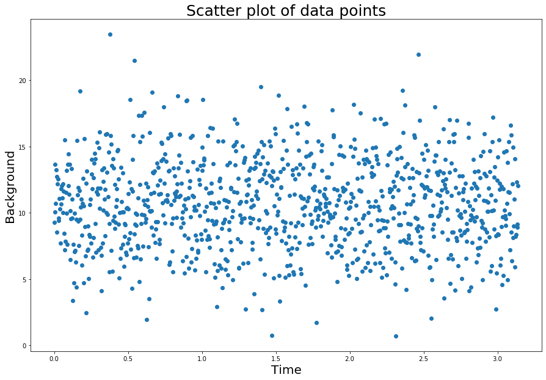

```python
data = bkgd[:1000]
Trange = t[:1000]
plt.scatter(Trange, data)
plt.xlabel('Time',fontsize = 20)
plt.ylabel("Background",fontsize = 20)
plt.title('Scatter plot of data points',fontsize = 25)
plt.show()
```

1b) Generalize your code so you can make a plot of any X contiguous points (e.g. 2000 points starting at point 500), and produce an example plot of a set of data somethere in the middle of your array.

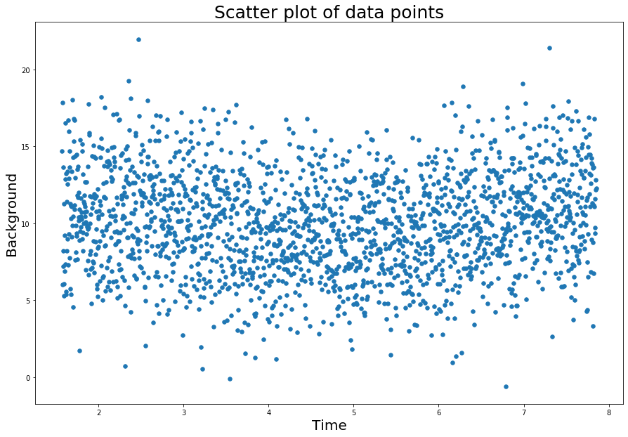

```python
def plot(trange,data,start,size):
    data = data[start:(start+size)]
    trange = trange[start:(start+size)]
    plt.scatter(trange,data,s=30)
    plt.xlabel('Time',fontsize = 20)
    plt.ylabel("Background",fontsize = 20)
    plt.title('Scatter plot of data points',fontsize = 25)
plot(t, bkgd, 500, 2000)
```

1c) Sometimes you want to sample the data, such as plotting every 100th point. Make a plot of the full data range, but only every 100th point.

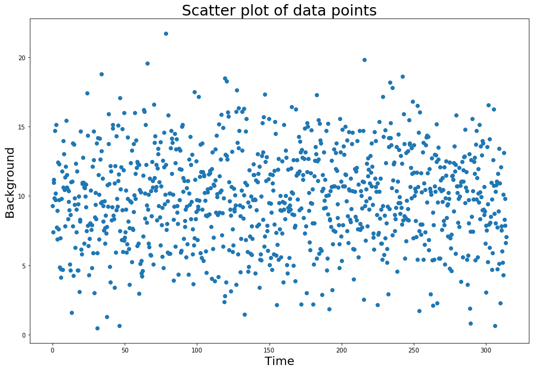

```python
def plot_every(x,t,bkgd):
    data=bkgd[np.arange(0,bkgd.shape[0],x)]
    plt.scatter(t[np.arange(0,bkgd.shape[0],x)],data)
    plt.xlabel('Time',fontsize = 20)
    plt.ylabel("Background",fontsize = 20)
    plt.title('Scatter plot of data points',fontsize = 25)
plot_every(100,t,bkgd)
```

Problem 2: density

Now you can make a scatter plot of just a 100,000 points, so you might try it to see what it looks like. But particularly in the central areas the points all overlap into just a blob, and this just gets worse as the number of points goes up. What is better is to plot the density of the points. There are several ways of doing this, but a 2D histogram plot is the easiest (plt.hist2d() in python and histogram2() in MatLab).

2a) Make a 2d histogram plot. Read about options, and play with binsize so it is useful (too large a bin and everything washes out, too small and the sample noise dominates). Make sure you use a colorbar.

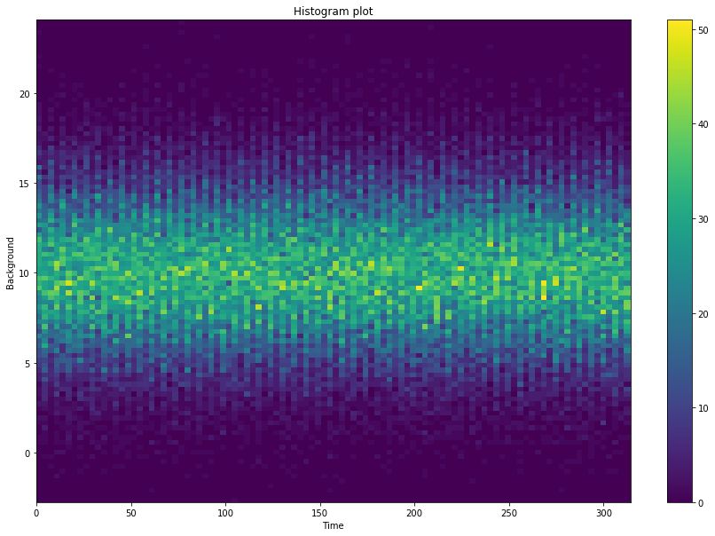

```python
plt.hist2d(t,bkgd,100)
plt.title("Histogram plot")
plt.xlabel("Time")
plt.ylabel("Background")
plt.colorbar()
plt.show()
```

2b) Clearly explain what is being plotted in your plot (e.g. what does each color mean?)

It is the distribution of the points and from the graph, we can see that most of the points are distributed around the area 5 to 15. The brightness represents the number of points in the area, for example, there are more points around the area 10 than other areas.

Problem 3: folding

Now if you have a periodic signal, it is possible to fold the data stream at that period to make the pattern clearer.

3a) Make an new time variable that folds at a period of 2π (the modulo operator is your friend, variably expressed as mod(), %, or rem()). Then make a scatter plot of all your data, but now folded. (Reminder, for more data you'd never actually want to plot all the points.)

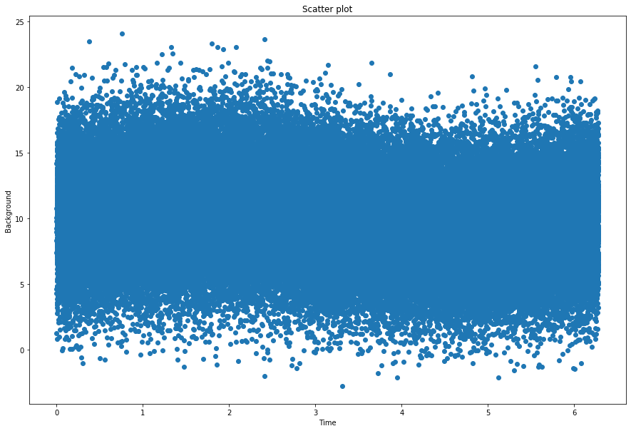

```python
newt = np.mod(t,(np.pi*2))
plt.scatter(newt,bkgd)
plt.title("Scatter plot")
plt.xlabel("Time")
plt.ylabel("Background")
plt.show()
```

3b) Make a 2D histogram plot of your folded data.

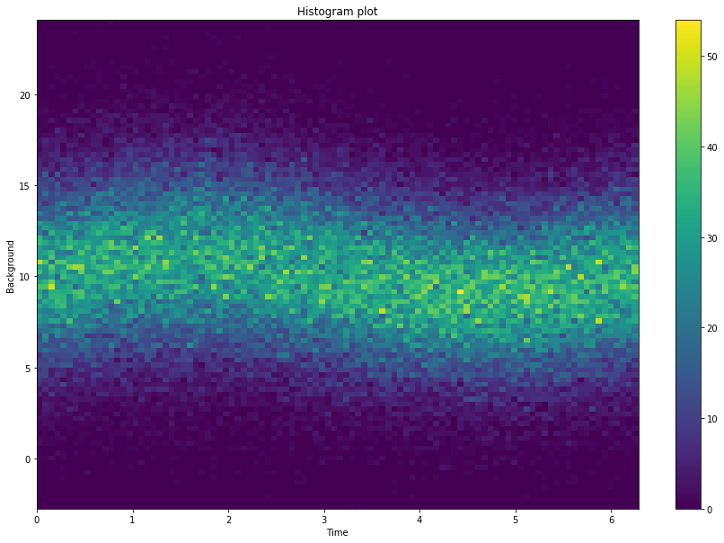

```python
plt.hist2d(newt,bkgd,100)
plt.title("Histogram plot")
plt.xlabel("Time")
plt.ylabel("Background")
plt.colorbar()
plt.show()
```